# Homework 01 - getting started

Melinda K. Higgins, PhD.

August 30, 2017

This document provides some suggested code and examples to get started on your homework 01.

## Get the data

The following code uses the `tidyverse` packages and workflow. As such these examples load (using the `library()` command) these packages:

- `tidyverse`
- `readxl`
- `forcats`

```r
# load tidyverse and readxl packages
library(tidyverse)
library(readxl)

# used read_excel() from the readxl package
dat <- read_excel("Dataset_02_fixq2.xlsx")
```

## do a basic summary

```r
# the summary() function gives you some basic summary stats
summary(dat)
```

```
##    SubjectID          Age          WeightPRE       WeightPOST
##  Min.   : 1.00   Min.   :24.00   Min.   : 60.0   Min.   :108.0
##  1st Qu.: 5.75   1st Qu.:35.75   1st Qu.:166.5   1st Qu.:154.8
##  Median :15.00   Median :44.00   Median :190.0   Median :190.0
##  Mean   :15.30   Mean   :44.80   Mean   :185.2   Mean   :184.7
##  3rd Qu.:23.25   3rd Qu.:50.00   3rd Qu.:230.0   3rd Qu.:216.2
##  Max.   :32.00   Max.   :99.00   Max.   :260.0   Max.   :240.0
##
##      Height           SES        GenderSTR          GenderCoded
##  Min.   :2.600   Min.   :1.00   Length:20          Min.   :1.000
##  1st Qu.:5.475   1st Qu.:2.00   Class :character   1st Qu.:1.000
##  Median :5.750   Median :2.00   Mode  :character   Median :1.000
##  Mean   :5.650   Mean   :1.95                      Mean   :1.421
##  3rd Qu.:6.125   3rd Qu.:2.00                      3rd Qu.:2.000
##  Max.   :6.500   Max.   :3.00                      Max.   :2.000
##                                                    NA's   :1
##        q1              q2              q3              q4
##  Min.   : 1.00   Min.   :1.000   Min.   :1.000   Min.   : 1.000
##  1st Qu.: 1.75   1st Qu.:2.000   1st Qu.:2.000   1st Qu.: 2.000
##  Median : 3.00   Median :4.000   Median :4.000   Median : 3.000
##  Mean   : 3.35   Mean   :3.421   Mean   :3.706   Mean   : 5.062
##  3rd Qu.: 4.25   3rd Qu.:4.000   3rd Qu.:5.000   3rd Qu.: 4.000
##  Max.   :11.00   Max.   :9.000   Max.   :9.000   Max.   :40.000
##                  NA's   :1       NA's   :3       NA's   :4
##        q5
##  Min.   :1.000
##  1st Qu.:2.000
##  Median :4.000
##  Mean   :3.882
##  3rd Qu.:5.000
##  Max.   :9.000
##  NA's   :3
```

## get some plots

Using the `tidyverse` workflow, the following code uses “pipes” which is the `%>%` symbol to take the output from one line as the input to the next line. So the code below can be read as “take the dataset called `dat` and send it (pipe it) into the `ggplot()` graphics environment and then add `+` a `geom` layer for a histogram using the `geom_histogram()` function.” To learn more about `tidyverse`, see https://www.tidyverse.org/. The “R Graphics Cookbook” is another fantastic resource for learning how to use `ggplot()` - see http://www.cookbook-r.com/Graphs/. There is a lot of great info and examples online, but you can also purchase the book on Amazon.

### Histogram of Age

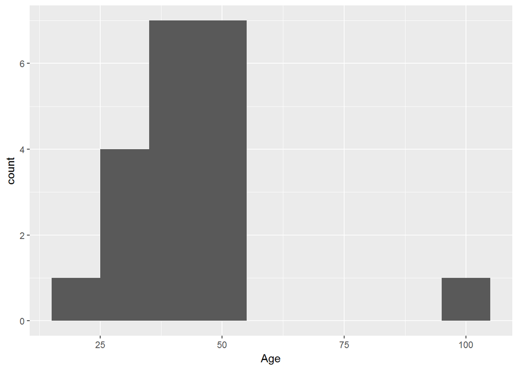

```r
dat %>%
  ggplot() +
  geom_histogram(mapping = aes(x = Age),
                 binwidth = 10)
```

### Bar chart of SES

This plot uses the `geom_bar()` graphics layer. However, you’ll notice that the categories still show the numeric codes. We could add labels manually, but it gets tedious to do this everytime.

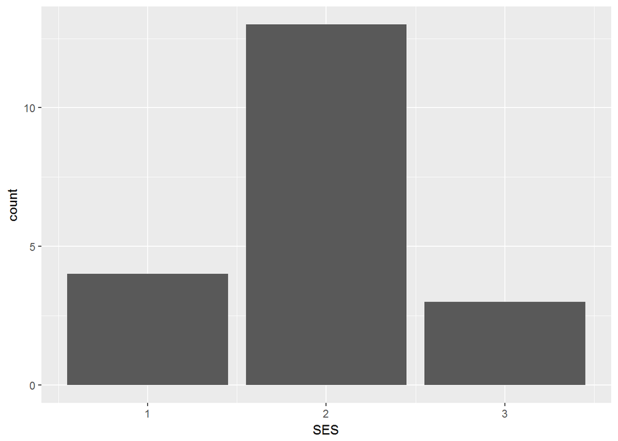

```r
dat %>%
  ggplot() +
  geom_bar(mapping = aes(x = SES))
```

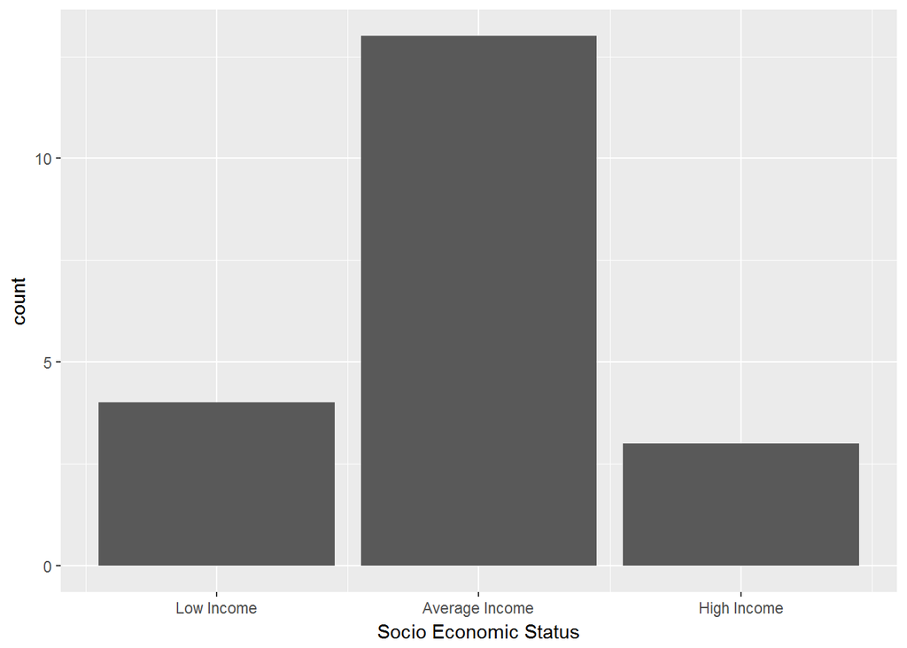

```r
# you can add an x-axis title and labels for the categories
dat %>%
  ggplot() +
  geom_bar(mapping = aes(x = SES)) +
  scale_x_continuous(name = "Socio Economic Status",
                   breaks = c(1,2,3),
                   labels = c("Low Income","Average Income",
                              "High Income"))
```

## add some factor level info - categorical and ordinal data

We can add the labels for the categorical and ordinal data by changes these variables into “factors”. In the `tidyverse` world, the package for this is `forcats`.

```r
# load the forcats package
library(forcats)

# create objects for the labels and levels for SES
sesLabels <- c("Low Income","Average Income", "High Income")
sesLevels <- c(1,2,3)

# apply the labels and levels for SES using the factor() function
dat$SES <- factor(dat$SES,
                  levels = sesLevels,
                  labels = sesLabels)
```

Now that we’ve create a factor type variable for SES, we can redo our bar chart but now the labels are automatically applied. We do not have to type them in separately using the `scale_x_continuous()` function in the `ggplot2` package.

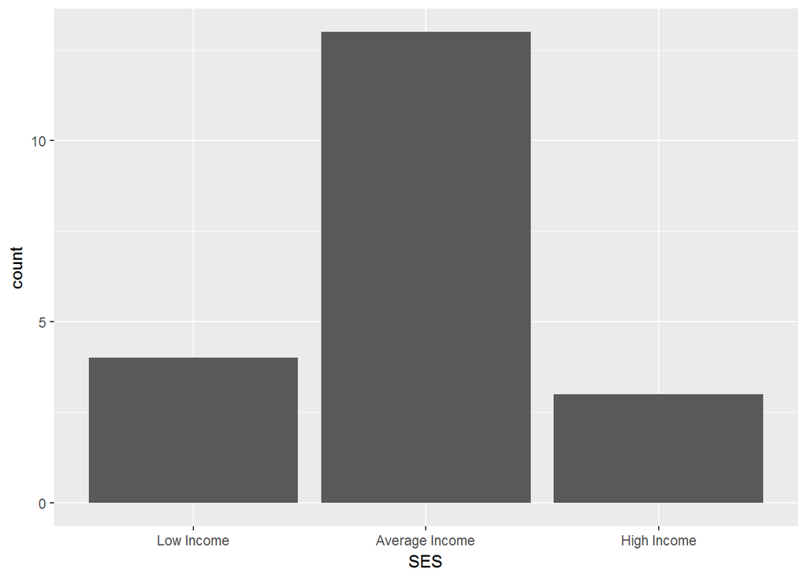

```r
# redo bar plot
dat %>%
  ggplot() +
  geom_bar(mapping = aes(x = SES))
```

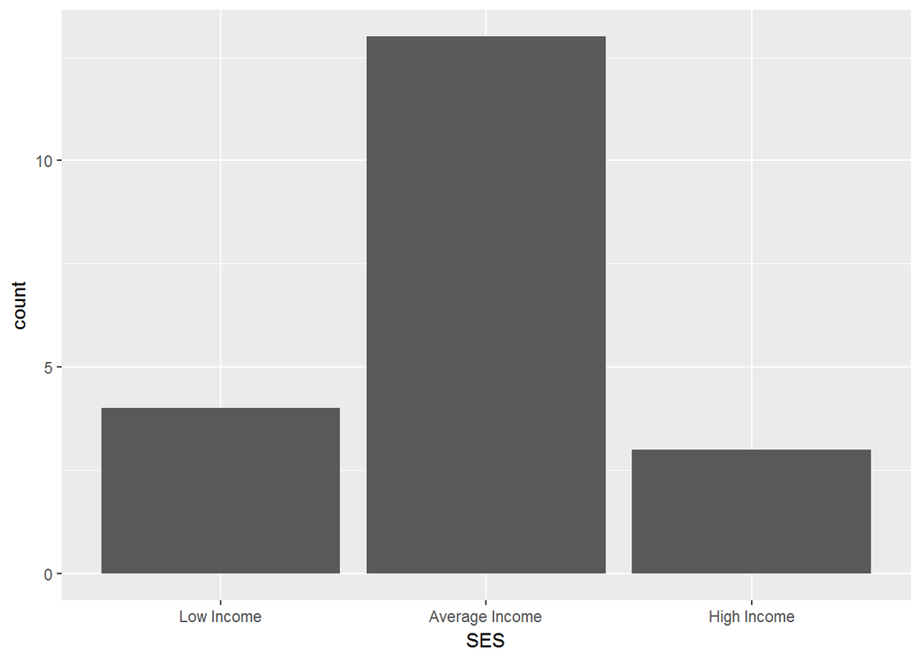

```r
# another way to do the bar plot
dat %>%
  ggplot(aes(SES)) +
  geom_bar()
```

## adding labels for the 5 LiKert scale questions q1,q2,q3,q4,q5

Using a similar workflow to what we did above for SES, let’s do it again for q1.

```r
# Likert scale coding for q1-q5
qLevels <- c(1,2,3,4,5)
qLabels <- c("None of the time","a little of the time","some of the time",
             "a lot of the time","all of the time")

# apply to q1 - you can redo this for the remaining 4 questions
dat$q1 <- factor(dat$q1,
                 levels = qLevels,
                 labels = qLabels)
```

In addition to providing labels in plotting routines, the factor coding also helps with the summary stats.

```r
summary(dat$q1)
```

```
##     None of the time a little of the time     some of the time
##                    5                    3                    3
##    a lot of the time      all of the time                 NA's
##                    4                    4                    1
```

And here is a plot of the q1 responses - notice that there are some missing values, `NA`s. There is a second plot made where these are removed using the `is.na()` function and the actual code uses `!is.na()` which says find the data that are NOT (`!`) missing.

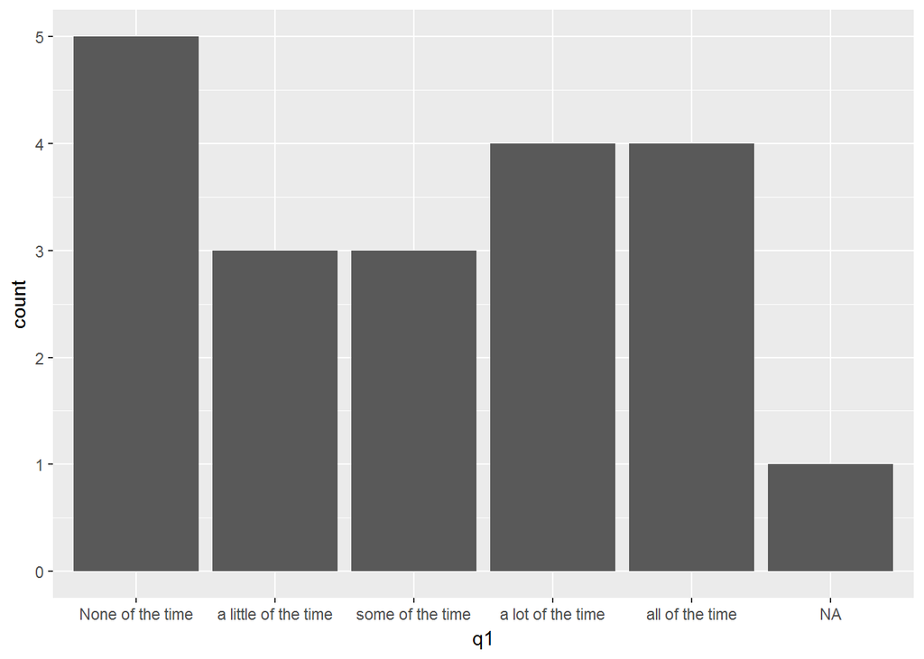

```r
dat %>%
  ggplot(aes(q1)) +
  geom_bar()
```

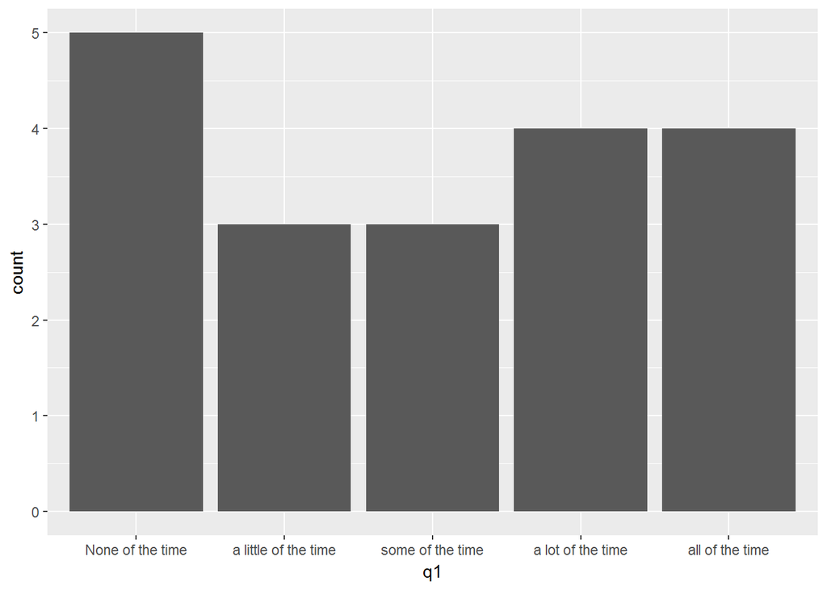

```r
# remove NAs and replot
dat %>%
  subset(!is.na(q1)) %>%
  ggplot(aes(q1)) +
  geom_bar()
```